# BayesExpression

Julin N Maloof

6/21/2017

```r
library(rstan)
rstan_options(auto_write = TRUE)
options(mc.cores = parallel::detectCores())
library(brms)
library(edgeR)
library(tidyverse)
```

Want to fit a model where:

- each gene has an intercept
- each gene has its own variance

## preliminaries

### get the data

You can also download it [here](http://jnmaloof.github.io/BIS180L_web/data/gh_internode_counts.tsv)

```r
counts.data <- read.delim("~/git/BIS180L_web/data/gh_internode_counts.tsv")
```

### create a data frame that describes the samples

```r
sample.description <- data.frame(
  sample=colnames(counts.data),

  #This next line searches for IMB211 or R500 in the colnames of counts.data and returns anything that matches
  #In this way we can extract the genotype info.
  gt=regmatches(colnames(counts.data),regexpr("R500|IMB211",colnames(counts.data))),

  #Now we use the same method to get the treatment
  trt=regmatches(colnames(counts.data),regexpr("NDP|DP",colnames(counts.data)))
)

# Now we can paste the trt and gt columns together to give a group identifier
sample.description$group <- paste(sample.description$gt,sample.description$trt,sep="_")

# set the reference treatment to "NDP"
sample.description$trt <- relevel(sample.description$trt,ref="NDP")

sample.description
```

```
##                                            sample     gt trt      group
## 1   IMB211_DP_1_INTERNODE.1_matched.merged.fq.bam IMB211  DP  IMB211_DP
## 2   IMB211_DP_2_INTERNODE.1_matched.merged.fq.bam IMB211  DP  IMB211_DP
## 3   IMB211_DP_3_INTERNODE.1_matched.merged.fq.bam IMB211  DP  IMB211_DP
## 4  IMB211_NDP_1_INTERNODE.1_matched.merged.fq.bam IMB211 NDP IMB211_NDP
## 5  IMB211_NDP_2_INTERNODE.1_matched.merged.fq.bam IMB211 NDP IMB211_NDP
## 6  IMB211_NDP_3_INTERNODE.1_matched.merged.fq.bam IMB211 NDP IMB211_NDP
## 7     R500_DP_1_INTERNODE.1_matched.merged.fq.bam   R500  DP    R500_DP
## 8     R500_DP_2_INTERNODE.1_matched.merged.fq.bam   R500  DP    R500_DP
## 9     R500_DP_3_INTERNODE.1_matched.merged.fq.bam   R500  DP    R500_DP
## 10   R500_NDP_1_INTERNODE.1_matched.merged.fq.bam   R500 NDP   R500_NDP
## 11   R500_NDP_2_INTERNODE.1_matched.merged.fq.bam   R500 NDP   R500_NDP
## 12   R500_NDP_3_INTERNODE.1_matched.merged.fq.bam   R500 NDP   R500_NDP
```

### normalize counts

```r
counts.data <- counts.data[rownames(counts.data)!="*",]
counts.data[is.na(counts.data)] <- 0
counts.data <- counts.data[rowSums(counts.data > 10) >= 3,]
dge.data <- DGEList(counts=counts.data, group=sample.description$group)
dim(dge.data)
```

```
## [1] 24034    12
```

```r
dge.data <- calcNormFactors(dge.data, method = "TMM")
dge.data$samples # look at the normalization factors
```

```
##                                                     group lib.size
## IMB211_DP_1_INTERNODE.1_matched.merged.fq.bam   IMB211_DP  5490779
## IMB211_DP_2_INTERNODE.1_matched.merged.fq.bam   IMB211_DP  1510063
## IMB211_DP_3_INTERNODE.1_matched.merged.fq.bam   IMB211_DP  5201394
## IMB211_NDP_1_INTERNODE.1_matched.merged.fq.bam IMB211_NDP  3900431
## IMB211_NDP_2_INTERNODE.1_matched.merged.fq.bam IMB211_NDP  3079339
## IMB211_NDP_3_INTERNODE.1_matched.merged.fq.bam IMB211_NDP  4769616
## R500_DP_1_INTERNODE.1_matched.merged.fq.bam       R500_DP  4824927
## R500_DP_2_INTERNODE.1_matched.merged.fq.bam       R500_DP  5591866
## R500_DP_3_INTERNODE.1_matched.merged.fq.bam       R500_DP  5130017
## R500_NDP_1_INTERNODE.1_matched.merged.fq.bam     R500_NDP  3189641
## R500_NDP_2_INTERNODE.1_matched.merged.fq.bam     R500_NDP  4519535
## R500_NDP_3_INTERNODE.1_matched.merged.fq.bam     R500_NDP  3941106
##                                                norm.factors
## IMB211_DP_1_INTERNODE.1_matched.merged.fq.bam     0.9599925
## IMB211_DP_2_INTERNODE.1_matched.merged.fq.bam     1.0071912
## IMB211_DP_3_INTERNODE.1_matched.merged.fq.bam     0.8859066
## IMB211_NDP_1_INTERNODE.1_matched.merged.fq.bam    0.9759586
## IMB211_NDP_2_INTERNODE.1_matched.merged.fq.bam    1.0014028
## IMB211_NDP_3_INTERNODE.1_matched.merged.fq.bam    0.9034489
## R500_DP_1_INTERNODE.1_matched.merged.fq.bam       1.0426105
## R500_DP_2_INTERNODE.1_matched.merged.fq.bam       1.0776337
## R500_DP_3_INTERNODE.1_matched.merged.fq.bam       1.0144761
## R500_NDP_1_INTERNODE.1_matched.merged.fq.bam      1.0596401
## R500_NDP_2_INTERNODE.1_matched.merged.fq.bam      1.0480216
## R500_NDP_3_INTERNODE.1_matched.merged.fq.bam      1.0445393
```

```r
data.cpm <- as.tibble(cbind(geneID=rownames(cpm(dge.data)),as.tibble(cpm(dge.data)),stringsAsFactors=FALSE))
colnames(data.cpm) <- sub("\\.1.*","",colnames(data.cpm))
head(data.cpm)
```

```
## # A tibble: 6 × 13
##      geneID IMB211_DP_1_INTERNODE IMB211_DP_2_INTERNODE
##       <chr>                 <dbl>                 <dbl>
## 1 Bra000002              3.794270             16.437397
## 2 Bra000003             43.254676             47.997199
## 3 Bra000005             62.226025             60.489620
## 4 Bra000006             21.247911             29.587314
## 5 Bra000007              2.276562              3.944975
## 6 Bra000008              3.794270              5.259967
## # ... with 10 more variables: IMB211_DP_3_INTERNODE <dbl>,
## #   IMB211_NDP_1_INTERNODE <dbl>, IMB211_NDP_2_INTERNODE <dbl>,
## #   IMB211_NDP_3_INTERNODE <dbl>, R500_DP_1_INTERNODE <dbl>,
## #   R500_DP_2_INTERNODE <dbl>, R500_DP_3_INTERNODE <dbl>,
## #   R500_NDP_1_INTERNODE <dbl>, R500_NDP_2_INTERNODE <dbl>,
## #   R500_NDP_3_INTERNODE <dbl>
```

### rearrange cpm

```r
data.tidy <- data.cpm %>%
  gather(sampleID,cpm,-geneID) %>%
  separate(sampleID,into=c("gt","trt","rep","tissue"))
head(data.tidy)
```

```
## # A tibble: 6 × 6
##      geneID     gt   trt   rep    tissue       cpm
##       <chr>  <chr> <chr> <chr>     <chr>     <dbl>
## 1 Bra000002 IMB211    DP     1 INTERNODE  3.794270
## 2 Bra000003 IMB211    DP     1 INTERNODE 43.254676
## 3 Bra000005 IMB211    DP     1 INTERNODE 62.226025
## 4 Bra000006 IMB211    DP     1 INTERNODE 21.247911
## 5 Bra000007 IMB211    DP     1 INTERNODE  2.276562
## 6 Bra000008 IMB211    DP     1 INTERNODE  3.794270
```

## get started

Start with voom transformed data and Gaussian distribution just to get our head around this

```r
voom.data <- voom(dge.data)$E
voom.data <- as.tibble(cbind(geneID=rownames(voom.data),as.tibble(voom.data),stringsAsFactors=FALSE))
colnames(voom.data) <- sub("\\.1.*","",colnames(voom.data))
voom.tidy <- voom.data %>%
  gather(sampleID,expression,-geneID) %>%
  separate(sampleID,into=c("gt","trt","rep","tissue"))
head(voom.tidy)
```

```
## # A tibble: 6 × 6
##      geneID     gt   trt   rep    tissue expression
##       <chr>  <chr> <chr> <chr>     <chr>      <dbl>
## 1 Bra000002 IMB211    DP     1 INTERNODE   1.959446
## 2 Bra000003 IMB211    DP     1 INTERNODE   5.437944
## 3 Bra000005 IMB211    DP     1 INTERNODE   5.961643
## 4 Bra000006 IMB211    DP     1 INTERNODE   4.415675
## 5 Bra000007 IMB211    DP     1 INTERNODE   1.245750
## 6 Bra000008 IMB211    DP     1 INTERNODE   1.959446
```

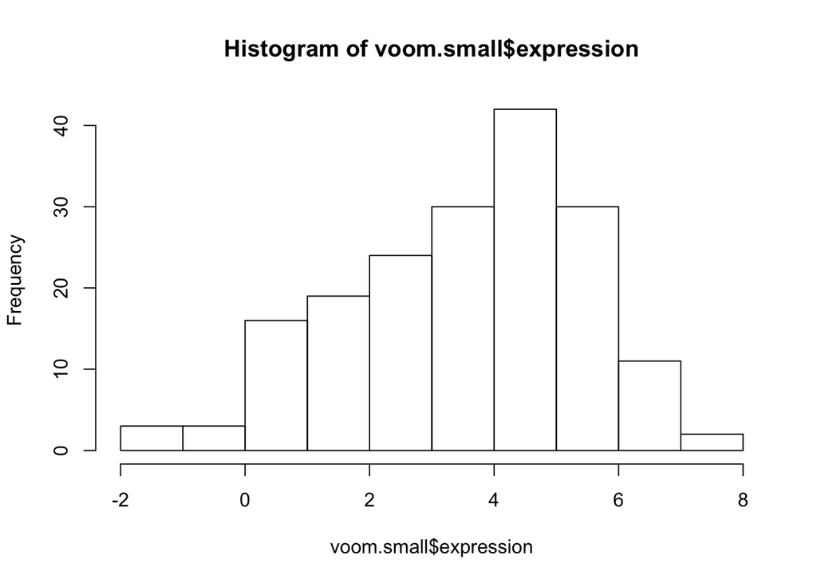

```r
voom.small <- voom.tidy %>% filter(gt=="IMB211" & trt=="DP" & startsWith(geneID,"Bra0000"))
hist(voom.small$expression)
```

What priors can we use in standard Gaussian?

```r
get_prior(expression ~ (1|geneID), data=voom.tidy)
```

```
##                 prior     class      coef  group nlpar bound
## 1                             b Intercept
## 2                     Intercept
## 3 student_t(3, 0, 10)        sd
## 4                            sd           geneID
## 5                            sd Intercept geneID
## 6 student_t(3, 0, 10)     sigma
```

### Standard Gaussian model with gene as random effect and non-hierarchical prior for sigma

```r
fit1 <- brm(expression ~ (1|geneID),
            prior=c(
              set_prior("normal(4,2)","Intercept"),
              set_prior("cauchy(0,1)","sd")),
            data = voom.small)
fit1
```

```
##  Family: gaussian(identity)
## Formula: expression ~ (1 | geneID)
##    Data: voom.small (Number of observations: 180)
## Samples: 4 chains, each with iter = 2000; warmup = 1000; thin = 1;
##          total post-warmup samples = 4000
##    WAIC: Not computed
##
## Group-Level Effects:
## ~geneID (Number of levels: 60)
##               Estimate Est.Error l-95% CI u-95% CI Eff.Sample Rhat
## sd(Intercept)     1.79      0.18     1.49     2.18        384 1.01
##
## Population-Level Effects:
##           Estimate Est.Error l-95% CI u-95% CI Eff.Sample Rhat
## Intercept     3.57      0.24      3.1     4.06        127    1
##
## Family Specific Parameters:
##       Estimate Est.Error l-95% CI u-95% CI Eff.Sample Rhat
## sigma     0.61      0.04     0.54     0.69       2411    1
##
## Samples were drawn using sampling(NUTS). For each parameter, Eff.Sample
## is a crude measure of effective sample size, and Rhat is the potential
## scale reduction factor on split chains (at convergence, Rhat = 1).
```

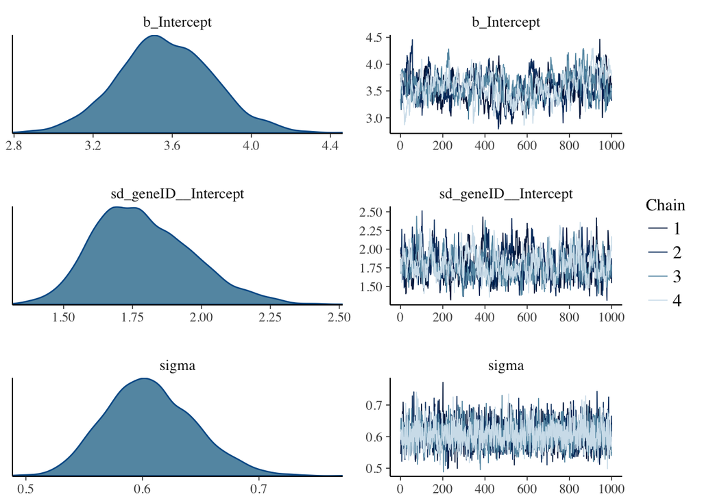

```r
plot(fit1)
```

### Gaussian, assigning different sigmas to different genes (As random effect)

what are the priors that can be set?

```r
get_prior(bf(expression ~ (1|geneID), sigma ~ (1|geneID)), data=voom.small)
```

```
##                  prior     class      coef  group nlpar bound
## 1                              b Intercept
## 2                      Intercept
## 3  student_t(3, 0, 10)        sd
## 4                             sd           geneID
## 5                             sd Intercept geneID
## 6                              b Intercept        sigma
## 7                      Intercept                  sigma
## 8  student_t(3, 0, 10)        sd                  sigma
## 9                             sd           geneID sigma
## 10                            sd Intercept geneID sigma
```

Do the fit specifying geneID as a (random) predictor of sigma

Must increase adapt_delta and number of iterations to get good sampling.

```r
fit2 <- brm(bf(expression ~ (1|geneID), sigma ~ (1|geneID)),
            prior=c(
              set_prior("normal(4,2)","Intercept")),
            data = voom.small,
            iter=10000,
            control=list(adapt_delta=0.99)
            )
fit2
```

```
##  Family: gaussian(identity)
## Formula: expression ~ (1 | geneID)
##          sigma ~ (1 | geneID)
##    Data: voom.small (Number of observations: 180)
## Samples: 4 chains, each with iter = 10000; warmup = 5000; thin = 1;
##          total post-warmup samples = 20000
##    WAIC: Not computed
##
## Group-Level Effects:
## ~geneID (Number of levels: 60)
##                     Estimate Est.Error l-95% CI u-95% CI Eff.Sample Rhat
## sd(Intercept)           1.81      0.18     1.50     2.20       2239    1
## sd(sigma_Intercept)     0.78      0.13     0.56     1.05       5000    1
##
## Population-Level Effects:
##                 Estimate Est.Error l-95% CI u-95% CI Eff.Sample Rhat
## Intercept           3.58      0.24     3.11     4.06       1157    1
## sigma_Intercept    -1.00      0.13    -1.26    -0.74       5914    1
##
## Samples were drawn using sampling(NUTS). For each parameter, Eff.Sample
## is a crude measure of effective sample size, and Rhat is the potential
## scale reduction factor on split chains (at convergence, Rhat = 1).
```

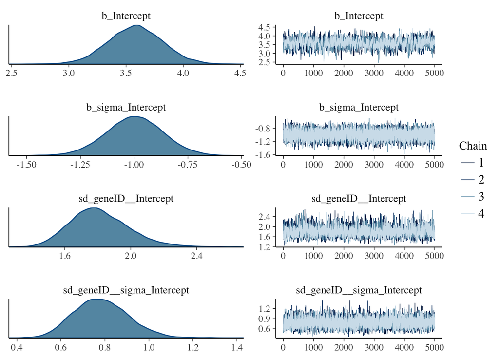

```r
plot(fit2)
```

### Compare models with and without hiearchical prior for sigma:

```r
loo(fit1,fit2)
```

```
##              LOOIC    SE
## fit1        404.61 41.58
## fit2        270.89 27.14
## fit1 - fit2 133.72 30.86
```

lower LOOIC is better, so there is strong evidence that having a hierarchical prior on sigma provides a better model fit.

### explore the fitted parameters

Get the estimated sigmas for each gene:

```r
str(ranef(fit2)) #we want the second one
```

```
## List of 2
##  $ geneID: num [1:60, 1] -0.519 1.852 2.353 0.802 -1.584 ...
##   ..- attr(*, "dimnames")=List of 2
##   .. ..$ : chr [1:60] "Bra000002" "Bra000003" "Bra000005" "Bra000006" ...
##   .. ..$ : chr "Intercept"
##  $ geneID: num [1:60, 1] 0.881 -0.483 -1.141 0.304 0.465 ...
##   ..- attr(*, "dimnames")=List of 2
##   .. ..$ : chr [1:60] "Bra000002" "Bra000003" "Bra000005" "Bra000006" ...
##   .. ..$ : chr "Intercept"
##   ..- attr(*, "nlpar")= chr "sigma"
```

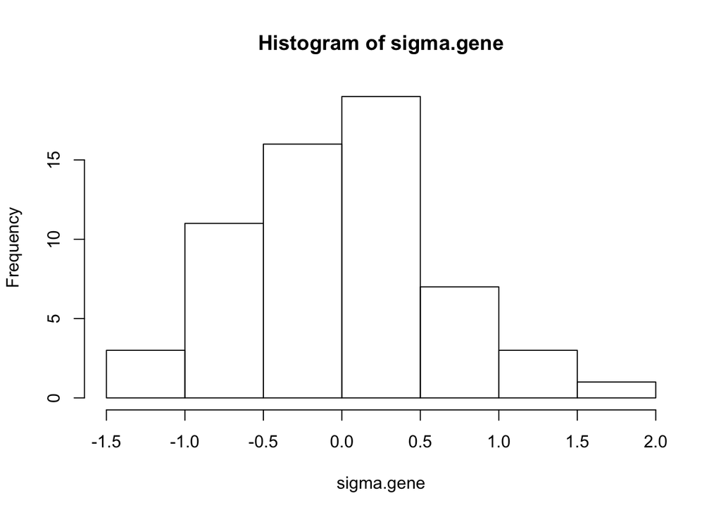

```r
# also, to get back on the original scale we need to take the exponential: see vignette("brms_distreg")
sigma.gene <- ranef(fit2)[[2]]
hist(sigma.gene) #how much the log_sigma is being adjusted for each gene
```

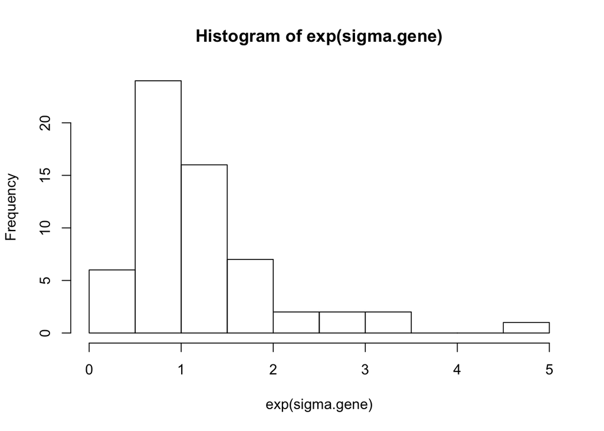

```r
hist(exp(sigma.gene)) #in sd units
```

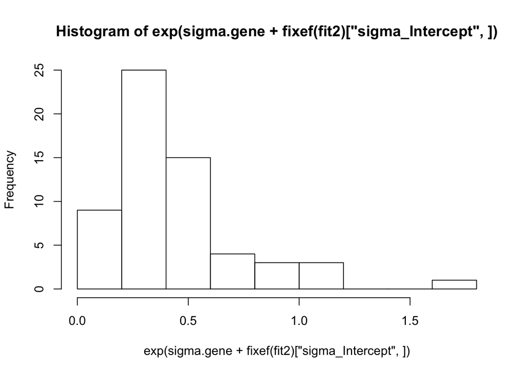

```r
hist(exp(sigma.gene+fixef(fit2)["sigma_Intercept",])) #actual sigma being used for each gene
```

To test whether an individual gene has higher standard deviation than average:

```r
hypothesis(fit2,"exp(r_geneID__sigma[Bra000002,Intercept] + b_sigma_Intercept) > exp(b_sigma_Intercept) ",class=NULL)
```

```
## Hypothesis Tests for class :
##                          Estimate Est.Error l-95% CI u-95% CI Evid.Ratio
## (exp(r_geneID__si... > 0     0.59      0.42     0.14      Inf     288.86
##                          Star
## (exp(r_geneID__si... > 0    *
## ---
## '*': The expected value under the hypothesis lies outside the 95% CI.
```

For all genes:

First define the tests we want to do

```r
tests <- parnames(fit2) %>%
  grep("r_geneID__sigma", . ,value=TRUE) %>%
  paste("exp(", . ," + b_sigma_Intercept) > exp(b_sigma_Intercept)", sep="")
head(tests)
```

```
## [1] "exp(r_geneID__sigma[Bra000002,Intercept] + b_sigma_Intercept) > exp(b_sigma_Intercept)"
## [2] "exp(r_geneID__sigma[Bra000003,Intercept] + b_sigma_Intercept) > exp(b_sigma_Intercept)"
## [3] "exp(r_geneID__sigma[Bra000005,Intercept] + b_sigma_Intercept) > exp(b_sigma_Intercept)"
## [4] "exp(r_geneID__sigma[Bra000006,Intercept] + b_sigma_Intercept) > exp(b_sigma_Intercept)"
## [5] "exp(r_geneID__sigma[Bra000007,Intercept] + b_sigma_Intercept) > exp(b_sigma_Intercept)"
## [6] "exp(r_geneID__sigma[Bra000008,Intercept] + b_sigma_Intercept) > exp(b_sigma_Intercept)"
```

run the test

```r
test.results <- hypothesis(fit2,tests,class=NULL)
```

look at the results

```r
rownames(test.results$hypothesis) <- rownames(test.results$hypothesis) %>%
  regmatches(. , regexpr("Bra[0-9]*",.))
test.results
```

```
## Hypothesis Tests for class :
##           Estimate Est.Error l-95% CI u-95% CI Evid.Ratio Star
## Bra000002     0.59      0.42     0.14      Inf     288.86    *
## Bra000003    -0.11      0.18    -0.29      Inf       0.22
## Bra000005    -0.21      0.15    -0.37      Inf       0.08
## Bra000006     0.18      0.28    -0.11      Inf       3.03
## Bra000007     0.27      0.30    -0.06      Inf       7.33
## Bra000008     0.07      0.23    -0.18      Inf       1.13
## Bra000009     0.05      0.23    -0.19      Inf       0.95
## Bra000011     0.03      0.22    -0.21      Inf       0.76
## Bra000012    -0.11      0.18    -0.29      Inf       0.21
## Bra000013    -0.13      0.17    -0.31      Inf       0.18
## Bra000015    -0.17      0.15    -0.34      Inf       0.11
## Bra000017     0.20      0.27    -0.10      Inf       3.74
## Bra000018     0.42      0.35     0.04      Inf      38.29    *
## Bra000023    -0.12      0.17    -0.30      Inf       0.19
## Bra000024     0.18      0.28    -0.12      Inf       2.95
## Bra000027     0.80      0.47     0.28      Inf    6665.67    *
## Bra000028    -0.05      0.20    -0.25      Inf       0.37
## Bra000029    -0.21      0.14    -0.37      Inf       0.07
## Bra000031     0.22      0.28    -0.09      Inf       4.52
## Bra000032    -0.15      0.16    -0.32      Inf       0.15
## Bra000034    -0.01      0.20    -0.23      Inf       0.58
## Bra000035    -0.18      0.14    -0.34      Inf       0.11
## Bra000036    -0.02      0.21    -0.24      Inf       0.51
## Bra000037    -0.15      0.16    -0.32      Inf       0.14
## Bra000038     0.09      0.25    -0.16      Inf       1.38
## Bra000039     0.35      0.33    -0.01      Inf      15.86
## Bra000042    -0.02      0.20    -0.23      Inf       0.50
## Bra000043     0.19      0.27    -0.10      Inf       3.41
## Bra000046     0.00      0.22    -0.22      Inf       0.62
## Bra000047     0.29      0.31    -0.04      Inf       9.62
## Bra000052     0.66      0.46     0.17      Inf     688.66    *
## Bra000053    -0.03      0.20    -0.24      Inf       0.45
## Bra000055    -0.06      0.20    -0.26      Inf       0.35
## Bra000056    -0.08      0.18    -0.28      Inf       0.28
## Bra000057    -0.21      0.15    -0.36      Inf       0.08
## Bra000059     1.46      0.69     0.69      Inf        Inf    *
## Bra000060     0.12      0.25    -0.15      Inf       1.78
## Bra000062    -0.11      0.17    -0.29      Inf       0.22
```

[output cut: 9 more lines]

```
## Bra000077     0.52      0.40     0.10      Inf     124.00    *
## Bra000080     0.27      0.30    -0.05      Inf       7.56
## Bra000081    -0.14      0.17    -0.31      Inf       0.15
## Bra000084     0.09      0.24    -0.16      Inf       1.43
## Bra000085    -0.02      0.20    -0.23      Inf       0.51
## Bra000088     0.04      0.22    -0.20      Inf       0.85
## Bra000089    -0.10      0.18    -0.29      Inf       0.23
## Bra000090     0.87      0.52     0.31      Inf   19999.00    *
## Bra000091     0.24      0.31    -0.08      Inf       5.16
## Bra000092     0.16      0.27    -0.12      Inf       2.61
## Bra000094     0.18      0.27    -0.11      Inf       3.28
## Bra000096     0.04      0.22    -0.19      Inf       0.88
## Bra000098    -0.14      0.17    -0.32      Inf       0.16
## ---
## '*': The expected value under the hypothesis lies outside the 95% CI.
```

## Reality check: plot the data

separate into different facets for the genes with “significantly” higher variance. Center (but don’t scale) to make for easier viewing.

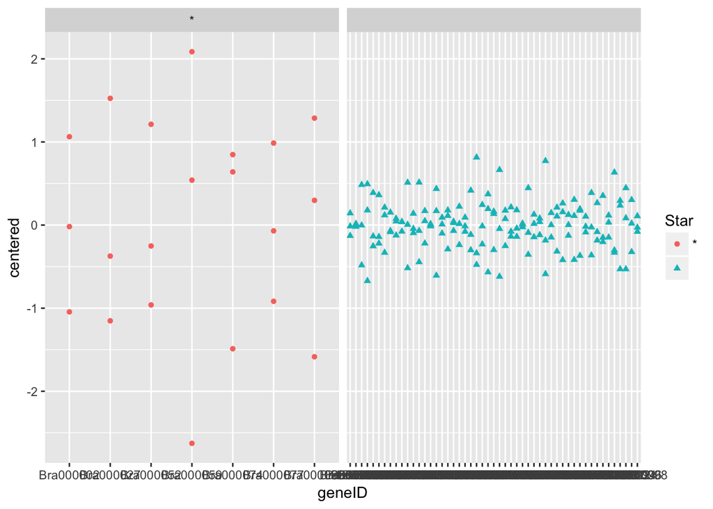

```r
voom.small$Star <- test.results$hypothesis[voom.small$geneID,"Star"]
pl <- voom.small %>%
  filter(!is.na(Star)) %>%
  group_by(geneID) %>%
  mutate(centered=expression-mean(expression)) %>%
  ggplot(aes(x=geneID,y=centered,shape=Star,color=Star)) +
  geom_point() +
  facet_wrap(~ Star, scales="free_x")
pl
```

**Looks good!**

## Next steps

- Incorporate genotype and treatment samples
- Try negative binomial fits

## starting with neg binomial

start with just a single sample type

```r
imbdp <- data.tidy %>% filter(gt=="IMB211" & trt=="DP" & startsWith(geneID,"Bra0000"))
imbdp
```

```
## # A tibble: 180 × 6
##       geneID     gt   trt   rep    tissue       cpm
##        <chr>  <chr> <chr> <chr>     <chr>     <dbl>
## 1  Bra000002 IMB211    DP     1 INTERNODE  3.794270
## 2  Bra000003 IMB211    DP     1 INTERNODE 43.254676
## 3  Bra000005 IMB211    DP     1 INTERNODE 62.226025
## 4  Bra000006 IMB211    DP     1 INTERNODE 21.247911
## 5  Bra000007 IMB211    DP     1 INTERNODE  2.276562
## 6  Bra000008 IMB211    DP     1 INTERNODE  3.794270
## 7  Bra000009 IMB211    DP     1 INTERNODE 49.325508
## 8  Bra000011 IMB211    DP     1 INTERNODE 16.505074
## 9  Bra000012 IMB211    DP     1 INTERNODE  9.485675
## 10 Bra000013 IMB211    DP     1 INTERNODE 10.623956
## # ... with 170 more rows
```

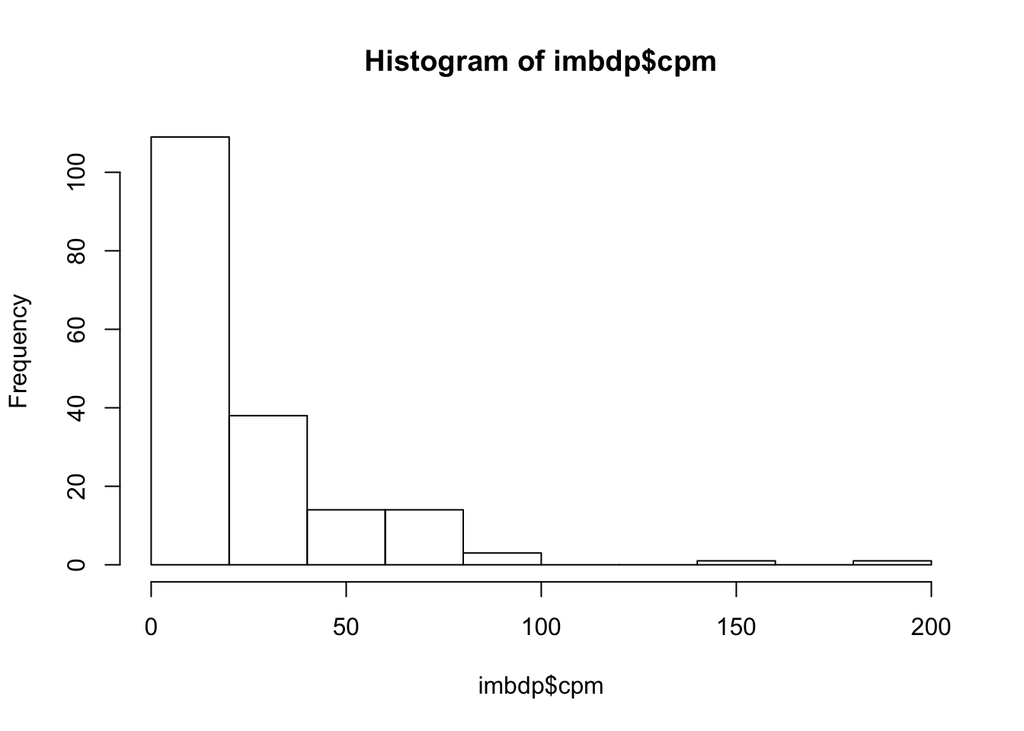

```r
hist(imbdp$cpm)
```

```r
get_prior(cpm ~ (1|geneID), data=imbdp)
```

```
##                 prior     class      coef  group nlpar bound
## 1                             b Intercept
## 2                     Intercept
## 3 student_t(3, 0, 27)        sd
## 4                            sd           geneID
## 5                            sd Intercept geneID
## 6 student_t(3, 0, 27)     sigma
```

```r
get_prior(cpm ~ (1|geneID), family="negbinomial", data=imbdp)
```

```
##                 prior     class      coef  group nlpar bound
## 1                             b Intercept
## 2                     Intercept
## 3 student_t(3, 0, 10)        sd
## 4                            sd           geneID
## 5                            sd Intercept geneID
## 6   gamma(0.01, 0.01)     shape
```